# Evaluating and Analyzing the LACCTiC API and Algorithim

**Disclaimer:** This is the source code which is meant to accompany the main report, all detailed analyses is explained in the report. Some packages (pandas and matplotlib are loaded twice (in function, and out of function).

When given the key for the API, the following instructions are also given: ``` Here is the main link to my API (the rest of this message is copy-pasted) https://c03mmwsf5i.execute-api.us-east-2.amazonaws.com/production/api_ranking/

The endpoints with "_page" roughly correspond to the pages on LACCTiC. You can look up "REST" frameworks to get a sense of how to navigate everything.

For a little example, https://c03mmwsf5i.execute-api.us-east-2.amazonaws.com/production/api_ranking/runner_page/ gives me a list of runners and their information. Because I have not specified a runner, I get a list of them. 75,000 would be a bit much all at once, so the results are "paginated." The attribute "next" in this class takes you to the link to the next page (which has a "?page=2" at the end of the URL).

Every runner, team, league, race etc has an "id" which is unique. To see a specific runner, you go to the same link as before but with the ID at the end of the URL. For example, https://c03mmwsf5i.execute-api.us-east-2.amazonaws.com/production/api_ranking/runner_page/12758/ gives the runner_page information for just Conner Mantz.

```
The data is stored in JSON format and there are three main data sources, each formatted with a different structure:
1. Runner pages - these pages show runner information and their results from each race they particiapted in
2. Race pages - these pages show results from a particular race
3. Team pages - these pages show roster information of any runner who has EVER raced for a particular team. (Team pages will be ignored for this analysis because needed team members for race will be within a given dataset for that particular race)
```

## Creating Functions to read each source type

Since reading in each source type may become repetitive, functions can and will be created so that each runner and race can be loaded into a pandas dataframe by simply inputting the runner or race ID. Functions are used throughout the notebook so that replicatability for a different race or performance can be conducted in the future.

```python
def LaccticRunnerToDF(runner_code): #creates a function which uses the LACCTiC runner code
    import urllib.request #for reading web data
    import json #for reading and converting JSON data
    import pandas as pd #for creating the pandas dataframe
    import io

    #takes the runner_code and inputs it into the url string and saves the link as runner_url
    runner_url = "https://c03mmwsf5i.execute-api.us-east-2.amazonaws.com/production/api_ranking/runner_page/"+str(runner_code)+"/?format=json"
    response = urllib.request.urlopen(runner_url) #opens the request and saves it as response
    json_string = response.read().decode('utf-8') #decodes the response in JSON format
    eq_parsed_json = json.loads(json_string) #parses the JSON into a dictionary
    runnerName = str(eq_parsed_json['firstname'] + ' ' + eq_parsed_json['lastname']) #saves the name of the runner
    seasonList = eq_parsed_json['season_ratings'] #creates a list of the season ratings from the dictionary

    races_df = pd.DataFrame() #creates an empty data frame

    for season in seasonList: #iterates through the list of season ratings, goes through season by season
        races = season['season_xc_performances'] #selects the season xc performances
        s = json.dumps(races) #parses the season xc performances
        season_df=pd.read_json(io.StringIO(s)) #loads the races from one season into a dataframe
        races_df = pd.concat([races_df, season_df], ignore_index=True) #appends that dataframe to the dataframe of all seasons

    #The race column in a dataframe is further nested and needs to be analyzed
    for index, row in races_df.iterrows():
        races_df.loc[index, 'date'] = row['race']['date'] #creates a date column from the race information
        races_df.loc[index, 'race_id'] = row['race']['id'] #creates a race ID column from the race information
        races_df.loc[index, 'race'] = row['race']['meet_name'] #creates a race name column from the race information
        races_df.loc[index, 'runner_name'] = runnerName #adds a runner name column, all the same, but can be useful for JOIN later

    #races_df.drop('significant', axis=1, inplace=True) #drops the dummy variable 1 if race has any significance


    print("Returning a Panda's DF for: " + runnerName) #prints to the console what the function is returning
    return(races_df) #returns a complete data frame of all races a runner has run.
```

```python
def LaccticRaceToDF(race_code): #creates a function which uses the LACCTiC race code
    import urllib.request #for reading web data
    import json #for reading and converting JSON data
    import pandas as pd #for creating the pandas dataframe
    import io

    #takes the race_code and inputs it into the url string and saves the link as runner_url
    race_url = "https://c03mmwsf5i.execute-api.us-east-2.amazonaws.com/production/api_ranking/race_page/"+str(race_code)+"/?format=json"
    response = urllib.request.urlopen(race_url) #opens the request and saves it as response
    json_string = response.read().decode('utf-8') #decodes the response in JSON format
    eq_parsed_json = json.loads(json_string) #parses the JSON into a dictionary
    results = eq_parsed_json['xc_results'] #selects the results from the xc race
    s = json.dumps(results) #saves the results to s
    race_df = pd.read_json(io.StringIO(s)) #converts the results of the race to a pandas dataframe

    for index, row in race_df.iterrows(): #the runner column needs to be further parsed to get data
        race_df.loc[index, 'runner_id'] = row['runner']['id'] #gets the runner_id from the runner section
        race_df.loc[index, 'team'] = row['runner']['team']['name'] #gets the team name from the runner section
        race_df.loc[index, 'runner_name'] = row['runner']['firstname'] + " " + row['runner']['lastname'] #gets the runner name from the runner section

    race_df.drop('runner', axis=1, inplace=True) #drops the runner column after it is iterated over

    raceName = str(eq_parsed_json['meet_name']) #saves the name of the race
    print("Returning a Pandas DF of race results for: " + raceName) #prints to the console what the function is returning
    return(race_df) #returns a complete data frame of all races a runner has run.
```

## Exploratory Research Questions

Using these functions to quickly load race and runner data, three exploratory research questions will be answered. These questions will be answered based off of the 2023 NCAA Cross Country Championship, for reasons outlined in the report.

**Research Question 1** (Race Source Based): Which teams performed the best and worst based on their predicted place by the LACCTiC alogrithm  
**Research Question 2** (Runner Source Based): After reading an individual's source page, can we examine if they have had significant improvement from year to year  
**Research Question 3** (*Joining* Runner and Race Sources): Which individuals at the national championship were the most consistent racers, and which indivudals had extreme (fast or slow) performance TiCs.

### Research Question 1: Which teams performed the best and worst based on their predicted place by the LACCTiC Alogrithim

First the function for races can be called to load the race data into a dataframe.

```python
NCAA2023Champs = LaccticRaceToDF(8187)
NCAA2023Champs
```

```
Returning a Pandas DF of race results for: NCAA Division I Cross Country Championships
```

|  | time | modern_tic | predicted_place | place | runner_id | team | runner_name |
| --- | --- | --- | --- | --- | --- | --- | --- |
| 0 | 1717.7001 | 6.677224 | 9 | 1 | 53652.0 | Harvard | Graham Blanks |
| 1 | 1720.7002 | 6.678969 | 8 | 2 | 89976.0 | New Mexico | Habtom Samuel |
| 2 | 1735.7003 | 6.687649 | 5 | 3 | 38094.0 | Stanford | Ky Robinson |
| 3 | 1739.7004 | 6.689951 | 2 | 4 | 90518.0 | Oklahoma State | Denis Kipngetich |
| 4 | 1743.8005 | 6.692305 | 12 | 5 | 24322.0 | Northern Arizona | Drew Bosley |
| ... | ... | ... | ... | ... | ... | ... | ... |
| 231 | 1982.7232 | 6.820709 | 171 | 232 | 61608.0 | Virginia | Justin Wachtel |
| 232 | 1982.8233 | 6.820760 | 199 | 233 | 12417.0 | Eastern Kentucky | Keeton Thornsberry |
| 233 | 1983.9234 | 6.821314 | 175 | 234 | 90187.0 | Villanova | Xian Shively |
| 234 | 1986.9235 | 6.822825 | 177 | 235 | 38113.0 | Butler | Jack McMahon |
| 235 | 2056.9236 | 6.857449 | 234 | 236 | 84563.0 | North Carolina | Luke Wiley |

236 rows × 7 columns

A performance_score column will be added to the data frame, where a positive predicted score indicates a better perofmance. (For example: Habtom Samuel's performance_score of 6 means he performed 6 places better than expected) A negative performance_score means a runner performed worse than expected.

```python
NCAA2023Champs['performance_score'] = NCAA2023Champs['predicted_place'] - NCAA2023Champs['place']
NCAA2023Champs
```

|  | time | modern_tic | predicted_place | place | runner_id | team | runner_name | performance_score |
| --- | --- | --- | --- | --- | --- | --- | --- | --- |
| 0 | 1717.7001 | 6.677224 | 9 | 1 | 53652.0 | Harvard | Graham Blanks | 8 |
| 1 | 1720.7002 | 6.678969 | 8 | 2 | 89976.0 | New Mexico | Habtom Samuel | 6 |
| 2 | 1735.7003 | 6.687649 | 5 | 3 | 38094.0 | Stanford | Ky Robinson | 2 |
| 3 | 1739.7004 | 6.689951 | 2 | 4 | 90518.0 | Oklahoma State | Denis Kipngetich | -2 |
| 4 | 1743.8005 | 6.692305 | 12 | 5 | 24322.0 | Northern Arizona | Drew Bosley | 7 |
| ... | ... | ... | ... | ... | ... | ... | ... | ... |
| 231 | 1982.7232 | 6.820709 | 171 | 232 | 61608.0 | Virginia | Justin Wachtel | -61 |
| 232 | 1982.8233 | 6.820760 | 199 | 233 | 12417.0 | Eastern Kentucky | Keeton Thornsberry | -34 |
| 233 | 1983.9234 | 6.821314 | 175 | 234 | 90187.0 | Villanova | Xian Shively | -59 |
| 234 | 1986.9235 | 6.822825 | 177 | 235 | 38113.0 | Butler | Jack McMahon | -58 |
| 235 | 2056.9236 | 6.857449 | 234 | 236 | 84563.0 | North Carolina | Luke Wiley | -2 |

236 rows × 8 columns

A traceplot of the performance_score by race place can be used to get a good feel of how the predictions performed throughout each place, the shape of the trend plot will be further analyzed in the report. A function to make the traceplot will be created so future traceplots can be analyzed if needed.

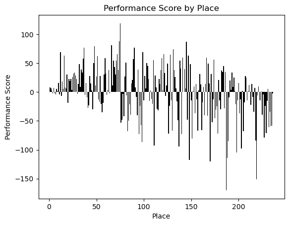

```python
def raceDFtoTracePlot(raceDF): #creates a function which requires a race dataframe
    import matplotlib.pyplot as plt
    plt.bar(raceDF['place'], raceDF['performance_score'], color='black') #plotting the trace plot
    #Adding Titles:
    plt.title('Performance Score by Place')
    plt.xlabel('Place')
    plt.ylabel('Performance Score')

raceDFtoTracePlot(NCAA2023Champs)
```

A pandas data frame can be "Grouped By" or pivoted so that teams can be the emphasis from this race data frame. The smallest performance score, average performance score, median performance score, and maximum performance score for each time will be described by this pivot. The output will be saved as a csv and further analyzed in the report.

```python
def raceGroupByTeamPS(raceDF):
    import pandas as pd
    groupedDF = pd.DataFrame() #declares an empty dataframe

    betaDF = raceDF.groupby(['team']).min(numeric_only=True) #grouping by the min
    groupedDF['Min'] = betaDF['performance_score']
    betaDF = raceDF.groupby(['team']).median(numeric_only=True) #grouping by the median
    groupedDF['Median'] = betaDF['performance_score']
    betaDF = raceDF.groupby(['team']).mean(numeric_only=True) #grouping by the mean
    groupedDF['Mean'] = betaDF['performance_score']
    betaDF = raceDF.groupby(['team']).max(numeric_only=True) #grouping by the max
    groupedDF['Max'] = betaDF['performance_score']
    return groupedDF

NCAA2023Groupteams = raceGroupByTeamPS(NCAA2023Champs)
NCAA2023Groupteams
```

| team | Min | Median | Mean | Max |
| --- | --- | --- | --- | --- |
| Air Force | -2 | 25.0 | 25.333333 | 60 |
| Alabama | -87 | -53.0 | -53.000000 | -19 |
| Arkansas | -170 | -7.0 | -20.714286 | 58 |
| BYU | -35 | 2.0 | 4.166667 | 48 |
| Boise State | 32 | 32.0 | 32.000000 | 32 |
| ... | ... | ... | ... | ... |
| Virginia | -151 | -37.0 | -32.857143 | 38 |
| Wake Forest | -94 | 40.0 | 19.714286 | 51 |
| Weber State | -14 | -14.0 | -14.000000 | -14 |
| Wingate | 87 | 87.0 | 87.000000 | 87 |
| Wisconsin | -114 | -0.5 | -5.666667 | 119 |

61 rows × 4 columns

```python
NCAA2023Groupteams.to_csv('ResearchQuestion1.csv', index=True)
```

### Research Question 2: After reading an individual's source page, can we examine if they have had significant improvment from year to year

With most runners spending three to five years in the NCAA system, the goal is to get faster and have better performances as you move throughout your college career. This next research question will have functions which allow for easy replicatability on any athlete. The top 3 athletes in the 2023 NCAA cross country meet will be saved as output to be analyzed in the report.

```python
def RunnerDFAnalyzeByYear(runner_df): #defining the function, taking in the "runner_df" variable
    import pandas as pd
    runner_df['date'] = pd.to_datetime(runner_df['date'], errors='coerce') #make sure the date column is date type
    runner_df['date'] = runner_df['date'].dt.year #converts the date to year
    runner_df = runner_df.groupby(['date']).min() #groups by year
    #eliminating unescceary columns:
    runner_df.drop('time', axis=1, inplace=True)
    runner_df.drop('race_weight_sig', axis=1, inplace=True)
    runner_df.drop('significant', axis=1, inplace=True)
    return runner_df
```

This function can be nested with the original LACCTiCRunnerToDF() function to quickly read,sort, and save the top 3 finishers

```python
ResearchQuestion2ABlanks = RunnerDFAnalyzeByYear(LaccticRunnerToDF(53652))
ResearchQuestion2ABlanks.to_csv('ResearchQuestion2ABlanks.csv', index=True)

ResearchQuestion2ASamuel = RunnerDFAnalyzeByYear(LaccticRunnerToDF(89976))
ResearchQuestion2ASamuel.to_csv('ResearchQuestion2ASamuel.csv', index=True)

ResearchQuestion2ARobinson = RunnerDFAnalyzeByYear(LaccticRunnerToDF(38094))
ResearchQuestion2ARobinson.to_csv('ResearchQuestion2ARobinson.csv', index=True)
```

```
Returning a Panda's DF for: Graham Blanks
Returning a Panda's DF for: Habtom Samuel
Returning a Panda's DF for: Ky Robinson
```

### Research Question 3: Which individuals at the national championship were the most consistent racers, and which indivudals had extreme (fast or slow) performance tics.

This final research question is the most complex as it requires joining the two different types of source documents together. This is the reason that runnerID is inputted as a column in a race data frame.

```python
NCAA2023ChampsRunnerID = NCAA2023Champs['runner_id'] #saving only the runner_ids column
```

Using the LaccticRunnerToDF() function and a for loop, the entire column can be iterated and all the races each runner has run can be created into one dataframe.

```python
import pandas as pd
AllRacesForNCAA2023Champs = pd.DataFrame() #creating an empty dataframe

for runner in NCAA2023ChampsRunnerID: #iterating through the column
    iteratedRunner = pd.DataFrame() #creating a second empty dataframe, which gets cleared before every iteration starts
    iteratedRunner = LaccticRunnerToDF(int(runner)) #calls the laccticRunnertoDF function and makes a dataframe
    AllRacesForNCAA2023Champs = pd.concat([AllRacesForNCAA2023Champs, iteratedRunner], ignore_index=True) #combines the two dataframes

AllRacesForNCAA2023Champs
```

```
Returning a Panda's DF for: Graham Blanks
Returning a Panda's DF for: Habtom Samuel
Returning a Panda's DF for: Ky Robinson
Returning a Panda's DF for: Denis Kipngetich
Returning a Panda's DF for: Drew Bosley
Returning a Panda's DF for: Nico Young
Returning a Panda's DF for: Patrick Kiprop
Returning a Panda's DF for: Brian Musau
Returning a Panda's DF for: Parker Wolfe
Returning a Panda's DF for: Fouad Messaoudi
Returning a Panda's DF for: Devin Hart
Returning a Panda's DF for: Victor Shitsama
Returning a Panda's DF for: Kirami Yego
Returning a Panda's DF for: Liam Murphy
Returning a Panda's DF for: Alex Maier
Returning a Panda's DF for: Sanele Masondo
Returning a Panda's DF for: Alex Phillip
Returning a Panda's DF for: Aaron Las-Heras
Returning a Panda's DF for: Perry Mackinnon
Returning a Panda's DF for: Victor Kiprop
Returning a Panda's DF for: Santiago Prosser
Returning a Panda's DF for: Jason Bowers
Returning a Panda's DF for: Rodger Rivera
Returning a Panda's DF for: Dylan Schubert
Returning a Panda's DF for: Brodey Hasty
Returning a Panda's DF for: Matthew Richtman
Returning a Panda's DF for: Tom Brady
Returning a Panda's DF for: Luke Combs
Returning a Panda's DF for: Nicholas Bendtsen
Returning a Panda's DF for: Nickolas Scudder
Returning a Panda's DF for: Chris Devaney
Returning a Panda's DF for: James Corrigan
Returning a Panda's DF for: Evans Kiplagat
Returning a Panda's DF for: Sam Lawler
Returning a Panda's DF for: Kenneth Rooks
Returning a Panda's DF for: Timothy Chesondin
Returning a Panda's DF for: Rodgers Kiplimo
Returning a Panda's DF for: Haftu Strintzos
Returning a Panda's DF for: Austin Vancil
Returning a Panda's DF for: David Mullarkey
```

[output cut: 181 more lines]

```
Returning a Panda's DF for: Jonathan DeSouza
Returning a Panda's DF for: Enock Kipchumba
Returning a Panda's DF for: Thomas Chaston
Returning a Panda's DF for: Silas Winders
Returning a Panda's DF for: Zane Bergen
Returning a Panda's DF for: Jonathan Carmin
Returning a Panda's DF for: Silas Derfel
Returning a Panda's DF for: Colton Sands
Returning a Panda's DF for: Caleb Niednagel
Returning a Panda's DF for: Harvey Cramb
Returning a Panda's DF for: Justin Wachtel
Returning a Panda's DF for: Keeton Thornsberry
Returning a Panda's DF for: Xian Shively
Returning a Panda's DF for: Jack McMahon
Returning a Panda's DF for: Luke Wiley
```

|  | time | modern_tic | race_weight_sig | significant | race | date | race_id | runner_name |
| --- | --- | --- | --- | --- | --- | --- | --- | --- |
| 0 | 1717.2001 | 6.687363 | 0.565449 | 1 | NCAA DI Championships | 2024-11-23 | 10175.0 | Graham Blanks |
| 1 | 1774.7001 | 6.719916 | 0.000000 | 0 | NCAA Division I Northeast Region Cross Country... | 2024-11-15 | 10112.0 | Graham Blanks |
| 2 | 1334.6001 | 6.693729 | 0.000000 | 0 | Ivy League Heptagonal Cross Country Championships | 2024-11-02 | 9900.0 | Graham Blanks |
| 3 | 1360.5002 | 6.692466 | 0.434551 | 1 | Wisconsin Pre-Nationals | 2024-10-19 | 9563.0 | Graham Blanks |
| 4 | 1717.7001 | 6.677224 | 0.402916 | 1 | NCAA Division I Cross Country Championships | 2023-11-18 | 8187.0 | Graham Blanks |
| ... | ... | ... | ... | ... | ... | ... | ... | ... |
| 3731 | 1916.8133 | 6.816961 | 0.000000 | 0 | NCAA Division I Southeast Region Cross Country... | 2023-11-10 | 8125.0 | Luke Wiley |
| 3732 | 1497.2091 | 6.792148 | 0.000000 | 0 | ACC Cross Country Championships | 2023-10-27 | 7822.0 | Luke Wiley |
| 3733 | 1511.9222 | 6.780028 | 0.527606 | 1 | Nuttycombe Invite | 2023-10-13 | 7593.0 | Luke Wiley |
| 3734 | 1487.9146 | 6.775412 | 0.472394 | 1 | Virginia Invitational | 2023-09-23 | 7154.0 | Luke Wiley |
| 3735 | 906.8015 | 6.783454 | 0.000000 | 0 | Charlotte Opener | 2023-09-01 | 6664.0 | Luke Wiley |

3736 rows × 8 columns

Next the dataframe will be filtered so that only races that took place in the 2023 season, the target sample, will be used.

```python
print(AllRacesForNCAA2023Champs['date'].dtype) #check the type of the date column

AllRacesForNCAA2023Champs['date'] = pd.to_datetime(AllRacesForNCAA2023Champs['date'], errors='coerce') #change the type to date
print(AllRacesForNCAA2023Champs['date'].dtype) #re-check the type of the date column
RacesForNCAA2023ChampsIn2023 = AllRacesForNCAA2023Champs[AllRacesForNCAA2023Champs['date'].dt.year == 2023] #only select 2023 races

RacesForNCAA2023ChampsIn2023
```

```
object
datetime64[ns]
```

|  | time | modern_tic | race_weight_sig | significant | race | date | race_id | runner_name |
| --- | --- | --- | --- | --- | --- | --- | --- | --- |
| 4 | 1717.7001 | 6.677224 | 0.402916 | 1 | NCAA Division I Cross Country Championships | 2023-11-18 | 8187.0 | Graham Blanks |
| 5 | 1771.6001 | 6.734465 | 0.000000 | 0 | NCAA Division I Northeast Region Cross Country... | 2023-11-10 | 8113.0 | Graham Blanks |
| 6 | 1427.4001 | 6.716947 | 0.000000 | 0 | Ivy League Heptagonal Cross Country Championships | 2023-10-28 | 7901.0 | Graham Blanks |
| 7 | 1403.4001 | 6.705545 | 0.330531 | 1 | Nuttycombe Invite | 2023-10-13 | 7593.0 | Graham Blanks |
| 8 | 1406.0001 | 6.722057 | 0.000000 | 0 | Battle in Beantown | 2023-09-29 | 7260.0 | Graham Blanks |
| ... | ... | ... | ... | ... | ... | ... | ... | ... |
| 3731 | 1916.8133 | 6.816961 | 0.000000 | 0 | NCAA Division I Southeast Region Cross Country... | 2023-11-10 | 8125.0 | Luke Wiley |
| 3732 | 1497.2091 | 6.792148 | 0.000000 | 0 | ACC Cross Country Championships | 2023-10-27 | 7822.0 | Luke Wiley |
| 3733 | 1511.9222 | 6.780028 | 0.527606 | 1 | Nuttycombe Invite | 2023-10-13 | 7593.0 | Luke Wiley |
| 3734 | 1487.9146 | 6.775412 | 0.472394 | 1 | Virginia Invitational | 2023-09-23 | 7154.0 | Luke Wiley |
| 3735 | 906.8015 | 6.783454 | 0.000000 | 0 | Charlotte Opener | 2023-09-01 | 6664.0 | Luke Wiley |

1234 rows × 8 columns

There are now 1234 races to join with the dataframe from the 2023 National championship. Before joining by name of runner, it should be made clear that all runners have unique names.

```python
NCAA2023Champs['runner_name'].describe()
```

```
count               236
unique              236
top       Graham Blanks
freq                  1
Name: runner_name, dtype: object
```

All names are unique, so the race data frame can be joined with the compilation of every race that these individuals ran in 2023

```python
JoinedNCAA2023Results = NCAA2023Champs.merge(RacesForNCAA2023ChampsIn2023, how='right') #uses the merge command to join
JoinedNCAA2023Results
```

|  | time | modern_tic | predicted_place | place | runner_id | team | runner_name | performance_score | race_weight_sig | significant | race | date | race_id |
| --- | --- | --- | --- | --- | --- | --- | --- | --- | --- | --- | --- | --- | --- |
| 0 | 1717.7001 | 6.677224 | 9.0 | 1.0 | 53652.0 | Harvard | Graham Blanks | 8.0 | 0.402916 | 1 | NCAA Division I Cross Country Championships | 2023-11-18 | 8187.0 |
| 1 | 1771.6001 | 6.734465 | NaN | NaN | NaN | NaN | Graham Blanks | NaN | 0.000000 | 0 | NCAA Division I Northeast Region Cross Country... | 2023-11-10 | 8113.0 |
| 2 | 1427.4001 | 6.716947 | NaN | NaN | NaN | NaN | Graham Blanks | NaN | 0.000000 | 0 | Ivy League Heptagonal Cross Country Championships | 2023-10-28 | 7901.0 |
| 3 | 1403.4001 | 6.705545 | NaN | NaN | NaN | NaN | Graham Blanks | NaN | 0.330531 | 1 | Nuttycombe Invite | 2023-10-13 | 7593.0 |
| 4 | 1406.0001 | 6.722057 | NaN | NaN | NaN | NaN | Graham Blanks | NaN | 0.000000 | 0 | Battle in Beantown | 2023-09-29 | 7260.0 |
| ... | ... | ... | ... | ... | ... | ... | ... | ... | ... | ... | ... | ... | ... |
| 1229 | 1916.8133 | 6.816961 | NaN | NaN | NaN | NaN | Luke Wiley | NaN | 0.000000 | 0 | NCAA Division I Southeast Region Cross Country... | 2023-11-10 | 8125.0 |
| 1230 | 1497.2091 | 6.792148 | NaN | NaN | NaN | NaN | Luke Wiley | NaN | 0.000000 | 0 | ACC Cross Country Championships | 2023-10-27 | 7822.0 |
| 1231 | 1511.9222 | 6.780028 | NaN | NaN | NaN | NaN | Luke Wiley | NaN | 0.527606 | 1 | Nuttycombe Invite | 2023-10-13 | 7593.0 |
| 1232 | 1487.9146 | 6.775412 | NaN | NaN | NaN | NaN | Luke Wiley | NaN | 0.472394 | 1 | Virginia Invitational | 2023-09-23 | 7154.0 |
| 1233 | 906.8015 | 6.783454 | NaN | NaN | NaN | NaN | Luke Wiley | NaN | 0.000000 | 0 | Charlotte Opener | 2023-09-01 | 6664.0 |

1234 rows × 13 columns

The "JoinedNCAA2023Results" data frame can now be grouped, ordered and sorted so that there is a strong indicator of each competitor's season via a quick glance.

```python
FinalOutput = pd.DataFrame() #creating an empty dataframe

#grabbing the min LACCTiC score
minDF = JoinedNCAA2023Results.groupby(['runner_name']).min(numeric_only=True)
FinalOutput['min_tic'] = minDF['modern_tic']

#grabbing the median LACCTiC score
medDF = JoinedNCAA2023Results.groupby(['runner_name']).median(numeric_only=True)
FinalOutput['median_tic'] = medDF['modern_tic']

#grabbing the max LACCTiC score
maxDF = JoinedNCAA2023Results.groupby(['runner_name']).max(numeric_only=True)
FinalOutput['max_tic'] = maxDF['modern_tic']

#Finding the tic range.
FinalOutput['tic_range'] = FinalOutput['max_tic'] - FinalOutput['min_tic']

#adding the NCAA place of each runner
FinalOutput['NCAA_Place'] = maxDF['place']

#addingthe tic from NCAA's
FinalOutput['NCAA_tic']=NCAA2023Champs.set_index('runner_name', inplace=False)['modern_tic']

FinalOutput
```

| runner_name | min_tic | median_tic | max_tic | tic_range | NCAA_Place | NCAA_tic |
| --- | --- | --- | --- | --- | --- | --- |
| Aaron Las-Heras | 6.706710 | 6.713347 | 6.723592 | 0.016882 | 18.0 | 6.706710 |
| Abdel Laadjel | 6.735604 | 6.744722 | 6.748714 | 0.013110 | 106.0 | 6.743779 |
| Abdelhakim Abouzouhir | 6.738011 | 6.742990 | 6.750157 | 0.012145 | 109.0 | 6.744323 |
| Abdirizak Ibrahim | 6.733002 | 6.735203 | 6.783142 | 0.050141 | 203.0 | 6.783142 |
| Abel Teffra | 6.753284 | 6.761864 | 6.791276 | 0.037992 | 159.0 | 6.761864 |
| ... | ... | ... | ... | ... | ... | ... |
| Yasin Sado | 6.734332 | 6.746884 | 6.763103 | 0.028771 | 73.0 | 6.734419 |
| Zach Hughes | 6.752287 | 6.774722 | 6.785640 | 0.033353 | 192.0 | 6.777365 |
| Zach Stewart | 6.771251 | 6.778628 | 6.796119 | 0.024869 | 195.0 | 6.778628 |
| Zachary Cloud | 6.760277 | 6.765889 | 6.795584 | 0.035307 | 212.0 | 6.789355 |
| Zane Bergen | 6.756685 | 6.789057 | 6.817309 | 0.060624 | 226.0 | 6.811538 |

236 rows × 6 columns

This new dataframe can now be sorted by tic_range to see which racers were most consistent. This output will be saved

```python
FinalOutput.sort_values(by='tic_range', axis=0, ascending=True, inplace=False)
```

| runner_name | min_tic | median_tic | max_tic | tic_range | NCAA_Place | NCAA_tic |
| --- | --- | --- | --- | --- | --- | --- |
| Corey Gorgas | 6.728850 | 6.730626 | 6.732070 | 0.003220 | 62.0 | 6.728850 |
| Adam Spencer | 6.729663 | 6.732603 | 6.735698 | 0.006035 | 70.0 | 6.732603 |
| Giedrius Valincius | 6.736004 | 6.741542 | 6.742293 | 0.006288 | 96.0 | 6.741542 |
| Evans Kiplagat | 6.713864 | 6.721170 | 6.723162 | 0.009298 | 33.0 | 6.713864 |
| Michael Morgan | 6.742252 | 6.746253 | 6.751858 | 0.009606 | 99.0 | 6.742252 |
| ... | ... | ... | ... | ... | ... | ... |
| Robert DiDonato | 6.723638 | 6.740148 | 6.800521 | 0.076883 | 49.0 | 6.723638 |
| Victor Shitsama | 6.699334 | 6.710528 | 6.780174 | 0.080840 | 12.0 | 6.699334 |
| Luke Wiley | 6.775412 | 6.787801 | 6.857449 | 0.082037 | 236.0 | 6.857449 |
| Jonas Gertsen | 6.748716 | 6.755286 | 6.832435 | 0.083719 | 144.0 | 6.755800 |
| Daniel McGoey | 6.739662 | 6.746786 | 6.848128 | 0.108466 | 112.0 | 6.745792 |

236 rows × 6 columns

```python
ConsistentRunners = FinalOutput.sort_values(by='tic_range', axis=0, ascending=True, inplace=False)
ConsistentRunners.to_csv('ResearchQuestion3.csv', index=True)
```

Finally, a plot will be made which will this tic_range to be better visualized to accompany the findings from the output:

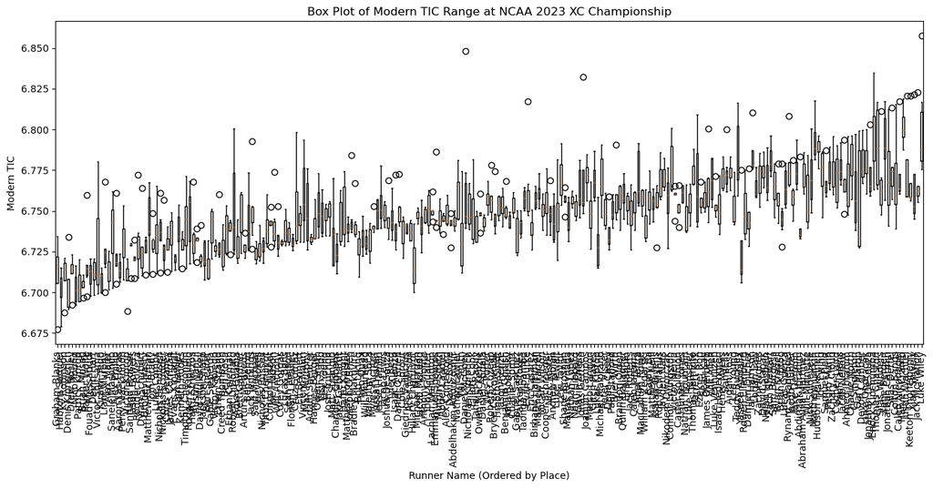

```python
import matplotlib.pyplot as plt

sorted_by_place = JoinedNCAA2023Results.sort_values(by='place') #sorting the columns by the NCAA place
runner_names_sorted_by_place = sorted_by_place['runner_name'].unique() #getting the names of each runner
#arranging the data for box plots:
data = [sorted_by_place[sorted_by_place['runner_name'] == runner]['modern_tic'] for runner in runner_names_sorted_by_place]

#making the plot:
plt.figure(figsize=(16, 6)) #adjusting size to be appropiate
plt.boxplot(data, tick_labels=runner_names_sorted_by_place)
# adding labels:
plt.title('Box Plot of Modern TIC Range at NCAA 2023 XC Championship')
plt.xlabel('Runner Name (Ordered by Place)')
plt.ylabel('Modern TIC')
plt.xticks(rotation=90) #rotating x-axis
plt.show()
```